# Suddenly Fiction

# CHAPTER 12

[figure not shown]

## Havre Dulac Grace is the name on his credentials.

He never liked his name, what was his parents thinking. He worked as a track and capture agent for the Taropian Enforcement Agency. Everyone just called it TEA. All of the agents had been law enforcement detectives, back when law and order was necessary. Nowadays all things were connected, literally. Once the teat, a binding life force entity thing, was manifested by the Mysterians, humanity and planet Earth changed forever. He was never sure he understood what teat was or how it worked, but it did. Precognition was as easy as breathing. You even knew what your cat was thinking.

Before the teat was released the Mysterians had been diviners and tarot readers. But somehow morphed over time, attaining true enlightenment, and discovering the teat. Once the teat got out, there was no putting the genie back in the bottle. Not easily. It bound everything and all life forms into a single collective of one easy access mind. Everything was plug and play now, with no privacy, no lying, and nothing on the down low. This change put law enforcement, justice, government, and the military out of business. The internet as well as broadcast radio and TV disappeared. All of those things were no longer needed. A sort of utopia was created and everything happened in your mind because of the teat force.

[figure not shown]

But as with all groups of people over the ages a split had formed. Factions broke off from the Mysterians. There now existed the Inners, Traders, Colabs, and Casters. None of them were as powerful as the Mysterians. These new groups pretended to be unaffected by the teat. But the teat connected all, whether you believe it or not. They preferred the old ways of divining by using tarot cards, omens seen, voices heard, or the casting of lots. Their numbers were small as their ways were seen as useless, now as ridiculous as belief and faith. In time another faction formed calling itself the Dires.

As former Mysterians the Dires had thorough knowledge of how the teat force worked. And over time, as a group working in unison, had developed a method to manipulate the teat within certain individuals. Once the Dire targeted a person their future was altered ending in their death. They simply put false information into the target's mind. Dires could perform this in a covert way, mostly covering their actions from the collective. Evil, of a sort, had returned. This is where Havre and others like him at TEA came in.

The Mysterians had secretly created a process to remove the teat from a person. Along with a drug, a person could extend the time spent outside the influence of the teat. They became as people once were, and no longer aware of being connected to everything. Havre did not like the process, as it took days in quarantine. Totally alone, in the dark, no voices in your head, and that old feeling of not knowing. Uncertainty returned, as you were slowly disconnected and unplugged. But the process was required otherwise the Dires would simply target a TEA agent. Before the process had been perfected, many agents lost their lives by being in the wrong place at the wrong time. Dire consequences.

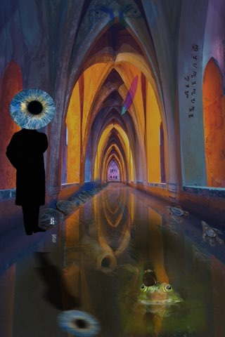

On the teat, then off the teat, became the pattern of life for Havre. It was confusing and exhausting. Once off the teat, he and other agents reverted to using the skills they had mastered as former detectives. Handcuffs, interrogations, and all. Along with a device provided by the Mysterians that could detect false thoughts within the collective.

There was a limit to the number of times a person could be taken off the teat.

This was Havre's last time before the force that was the teat would resist the process. Winking in and out of different realities as he had done for many years, Havre was unsure about his future. A strange feeling in a world where your future was a certainty.

[figure not shown]

# CHAPTER 13

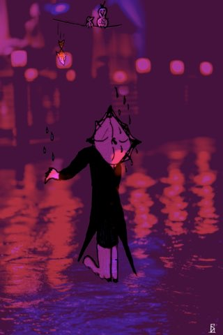

## She had walked right on past twilight.

It was too dark to see much of anything. No moon, no stars, just rain. Tired and hungry she found a tree just off the path to sit against. A taste of freedom occurred to her. For the first time in her life there wasn't anything she really had to do. The rain poured, the tears poured, her thoughts poured. With her back against an old tree she let it all flow through and around. There were thoughts, worries really, about an unknown future. She let those flow away as well. She fell asleep.

After waking, she decided that from now on her name would be Belles. She liked the sound of it. The rain had stopped, the path was muddy, the mud would slow her down but it felt soft on her feet. So off to town she went. What to do next, she decided, was left in the hands of fate. For now, she would notice all of the things around her as she walked. The sun popping in and out between the clouds, the mud squishing between her toes, the songs of birds glad the rain had ceased, and the splashing sounds of water rushing over rocks in a nearby stream. Appreciating the surroundings seemed to alleviate her suffering. Being chilled, damp, hungry, and naked was all still there, but her steps seemed lighter and quicker today. She wondered if this might be a thing called hope.

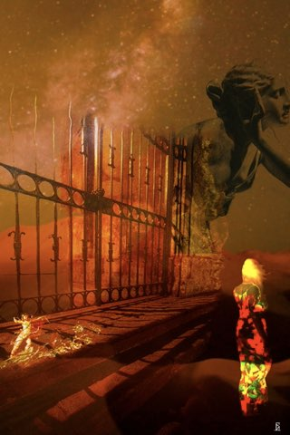

As she reached the outskirts of town, it seemed best to not stay out in the open. A naked woman draws too much attention, especially from men, even the so called honorable ones. She vaguely recalled delivering bacon to a widow and her daughter on the edge of town. One of her rare trips into town with Zeke. Discretely she traipsed through a couple of backyard gardens. Stopping and squatting down in a garden near what looked like a row of carrots. She thought this might be the place.

She was about to pull up a carrot when an old woman's voice commanded her to stop.

She froze.

# CHAPTER 14

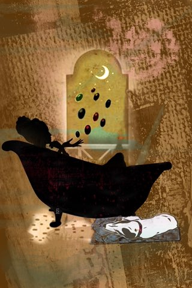

## There she laid. Sleeping again.

She slept a lot. On the floor, or curled in a chair, or a sofa either upside down on her back or on her side. She never watched TV, as if it wasn't even turned on and didn't exist. Just staring at us while we locked eyes onto that TV tube. Let your eyes linger too long into her eyes and she was triggered. As if your eyes had said come, let's play. Once begun, it always played out the same. Slobbery exchanges of various toys; balls, stuffed squeaky animals, and rope pulling and tugging.

Her name was Molly. A mix of Lab and Husky. One blue eye, one milky brown eye. Slightly overweight at 90 pounds, otherwise perfectly happy in demeanor. I remember her tail thumping and pounding the floor as she lay half asleep upon my approach. Every time, for over fifteen years. She was a nice old big dog who loved everyone she met. If you fell asleep on the sofa, you would awake to her somehow being sprawled on top of you. Love on all fours.

[figure not shown]

For the most part, she was the same as every other pet dog I've known, with one exception. Molly came up with this on her own, no training. It happened every time, just let her out into the backyard, a sort of self walkies plus me being lazy sometimes, then I would sit on the porch steps watching. After *doing her business*, she would always dash back up the steps then turn around. Approaching from behind, she would force her head between my body and arm.

Imposing a hug.

We would just sit there in a hug and watch the world go by. I miss her.

# CHAPTER 15

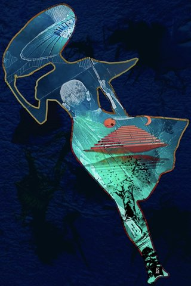

## Lorelei was adorable.

Cute, petite, nice, sweet, with a light bulb shaped head, very short spiked hair except for a long braided rat tail down to her bottom. Also nice. Every week a different, all natural, dyed hair color. She always whispered when she spoke. But she seemed totally unaware of all of that, which made her all the more adorable. Well, to me. She was an avid reader of everything, it seemed. Apparently lots of avid readers are also drop outs from college. That's how we met. I was a night manager at a bookstore. She shelved books and helped customers find books to read. Most of the employees were drop outs or just adrift in one of life's doldrums.

In time we hung out more and longer. I may have been falling for her. But some things bugged me. First, every day she felt compelled to reassess where our relationship stood. She liked me yesterday, but not so much today. She liked me more today than yesterday. She thought she might be falling in love, yet unsure it was love, exactly. And so on. She expected me to respond in kind, but I never knew what to say. I liked her, she was adorable, comfy, and cozy. Time will tell, I thought. Second, she was absolutely certain that she could only really truly fall in love with someone who took a stand in life. An activist, a revolutionary, a radical. I thought most of those folk die young. Then she expressed a strong attraction to young Neo-Nazi men. She liked that they were tall, skinny, tattooed, and stern looking. I felt her slipping away.

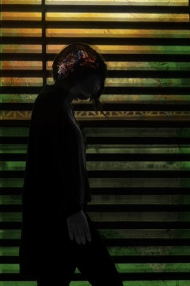

Soon we became just friends again. Sometimes we took work breaks together. I snacked and listened as she whispered about how Neo's were very different than older Nazi's. She insisted that times have changed. She was still adorable, mostly.

# CHAPTER 16

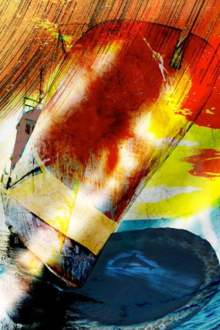

## Covered in the salt of sea and sweat, baked by the sun, I was crisped all over.

Somehow I was adrift upon a sea in a dinghy with few supplies. I had memories, but none about the how's and why's of being here. It seemed there was a natural current, a flow to the water, but I was bound and determined to paddle in the opposite direction. A challenge with only one oar and no sail. I felt confused and lost but not anxious or worried. By day I seemed to be moving forward, a tiring effort. By night, with sleep, I seemed to drift back again. Stubbornly I wanted to escape this doldrums no matter the cost. Every day, the same again.

One evening my daily ever repeating pattern was broken. As I rested, drifting backwards yet again, I saw a large sailboat approaching. It glistened in the moonlight, all spit shined and polished. Rescued, at last, despite it heading in the opposite direction of my stubbornness. As it drew nearer I could see the vessel bristled with canons and flew the Jolly Roger flag. Not an encouraging sign, but what threat was a lone exhausted man in a one oared dinghy. None. Drifting along her starboard side, I could see people onboard, most were clutching the side railing. Strangely, without thinking about it, I recognized them all as famous writers of fiction. How could I know this, for I wasn't well read, as best as I could recall.

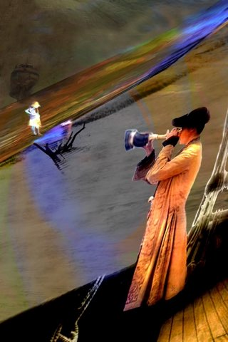

As I slipped past and upon a closer view it was as if I knew each one of them personally, from somewhere or sometime, I knew not. At the bow was Poe holding up a lantern staring at some unseen thing out beyond the horizon. A picture of melancholy was he. Just aft of Poe was Bronte, she gazed at him like an unrequited love. Her heart felt broken. Next came Shelley looking greenish bent over the railing. Her hair was being held back by Stoker as she wretched. Further down in the hull, below deck, I noticed flickering lights and movements in several portholes, one framed the scared face of the King of horror himself. Then my eyes caught clamberings amongst the masts, ropes, and sails. Our champion Vonnegut was maddeningly lashing this and battening that. Now I drifted passing two lovers, perhaps, on the stairs to the helm. It was Hemingway with an arm around Lavid. She was bedecked in pinks of all shades and sorts. Silks, cottons, and velvets all a fluttering in the wind. He jibbed in her ear Dolly, more telltales of flash fiction! Upon reaching the helm I saw that the skipper at the big wheel was Melville, seemingly continuing his age old arguments with a phantom Starbucks. At the back of the stern holding a big brass telescope was a silent Yeats. He seemed to be peering at the moon.

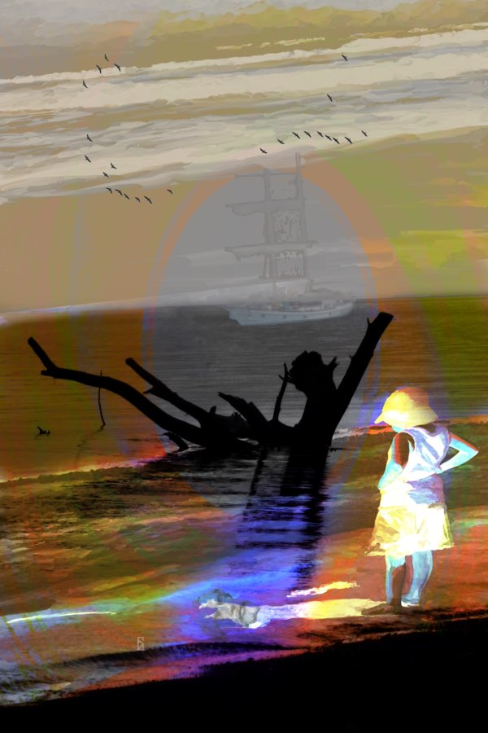

Tonight's moon was a super sized one, casting pinkish and orangish hues in the heavens and the sea. As it sailed away from me I saw painted on her stern "H.M.S. Purrlitzer", an unlikely name for either a pirate or a ghost ship. I had not cried out to be rescued. I laid back gazing at the moon and the stars with a smile. The doldrums are just fine, I resumed my stubbornness.

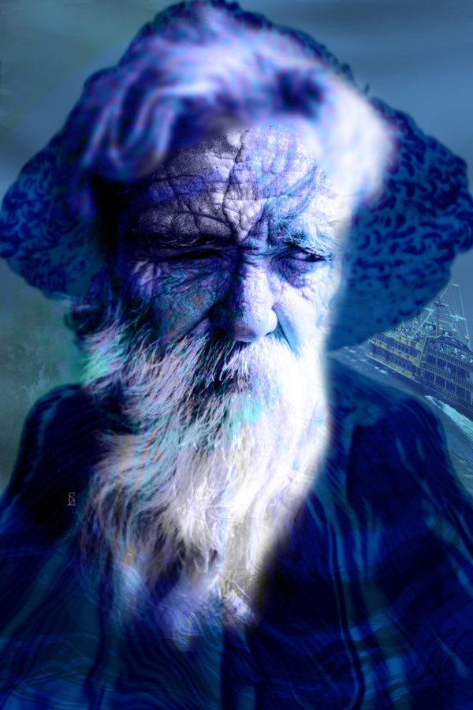

# CHAPTER 17

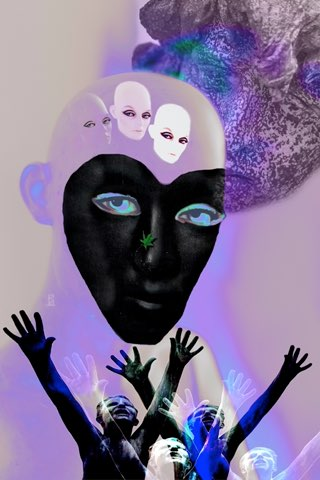

## There we laid on our sides, back to front or front to back, depending.

Like spoons she called it. Her favorite position she said. Though I was never quite certain who it was that I was spooning with. She was an actress, always in this or that character. A living rehearsal she called it. I found it confusing. I wanted to like her, to get to know her, not all of them, just her.

Her name was Cherri, pronounced like sherry, she said. We met at a little theater community play she performed in, one of Shakespeare's I think. At the after party I told her she was great. She seemed to soak up praise, genuine or not, like a sponge. I had noticed her before as an assistant in a college theater class. She was a senior and I was a sophomore. As a townie, she lived nearby off campus in her own house. All alone, except the house was filled with books and clothes. Reading, dressing up, and pretending was her life. Being with her was a nice change from dormitory life. I felt a bit spoiled. Perhaps I was really only attracted to her eccentricities, she was unlike anyone I have ever fallen for. Maybe I was mesmerized or spellbound, enchanted in some way I did not understand. In time that feeling would fade. As I could never get her to be her true self, or if she ever was herself, I could not tell.

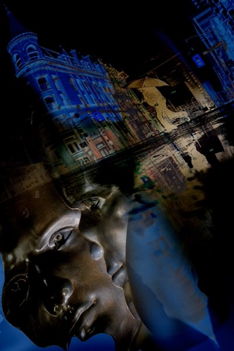

She reminded me of the story of Sybil. While fiction, it was a story about a functioning person with multiple personalities. Similar to a disorder I had read about in a psychology course. Near the end of my relationship with Cherri, we talked about mental disorders. She had very firm opinions about disorders. Questioning what was disorder and what was order, both subjective she said. Stating that some people are aware that certain choices in life may lead to an appearance of disorder. Many years later I would come to understand and appreciate some of what she had said.

She remains a fond memory.

I liked her, but never really knew her, or any of them, not really.

# CHAPTER 18

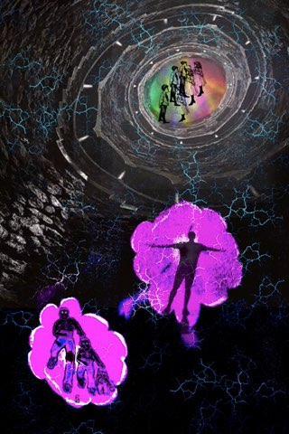

## Mornings before school were a balancing act.

Unmatched by even the Cirque Du Soleil. Most days there was a tiny horde of ten to thirteen kids, along with a cat and dog, all bellied up to the trough awaiting to be fed. Five of those kids were the fruit of my loins. The others were their freeloading friends. Each of them had their own breakfast vices. But mostly they all wanted an omelette, in all the ways those could be created. Moments such as this are possibly best remembered in the future, when the details get tinted by that rose colored fog that only occurs in memories.

A daydream had taken me back to those times. Bringing back feelings of being hectic and scatterbrained. The dream waxed and waned with a swirl of remembered activity, once commonplace, now seemingly an impossible task at the break of dawn. In and out came the rumblings of youth, the whisking of eggs in separate bowls mixed with water or milks, closely watching those four fry pans on the stovetop while butter or oil sizzled, then the finale of wielding a spatula for the plating. All to appease the hungry. I watched while they wolfed it down as if this was not a daily thing. The night always reset them. That flurry always ended with some chow for the awaiting cat and dog, who had already begged morsels of omelette from a few of the sympathetic. Begging works, if you have fur and a tail. I never ate. There wasn't time. Now it was off to school for them all. Then back home to clean up, make lists, ensure tomorrow was a repeat performance.

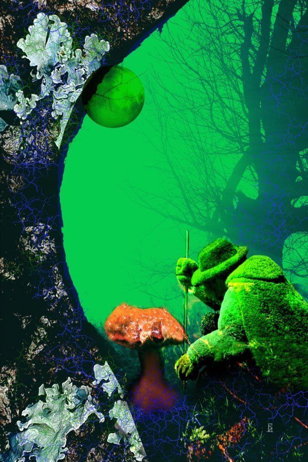

Even with the blessing of daydreaming, it all seemed distant and devoid of long ago emotions. Something was missing. Once awake again I did recall an old thought. Those days always seemed as if from a fairytale with kids starring as dwarves. Each dwarf playing out in various ways some aspect of my own persona and moods. Still something was missing.

# CHAPTER 19

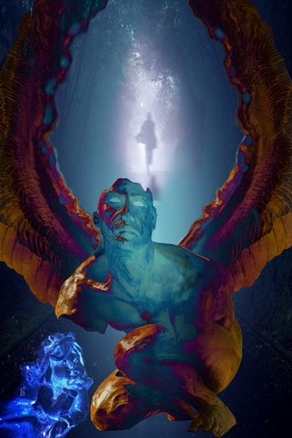

## Some memories seem as if from a past life, time changes so many things.

There is a memory that lingers, vividly, an iridescent shimmer of a series of firsts. Her name was Sue. We were both seniors in high school. Different high schools, she attended a Catholic private school, me a public school. We actually met while doing volunteer work at a hospital. She was a candy striper delivering flowers to patients. I assisted burn victims receiving fitness and wax therapies. Sue was a tall tanned long legged blonde, friendly, but a bit of a tomboy. She was the first girl I ever worked up the nerve to ask out on a date. A real date, no chaperone, in a car borrowed from my uncle.

Our first date, she decided, would be a picnic. I had no clue what that meant. But there we were barefoot on a blanket in a park with a basket of goodies her mother put together. We talked and nibbled on nuts dipped in chocolate, cheeses, crackers, and sliced fruits. To me she seemed smart, smarter than me, but she was a good listener, and not chatting away endlessly. Often we were silent, just looking into each other's eyes. Our feet touched sometimes, tingles. Soon her feet were doing all sorts of things. She had talented toes, I think this was my first footsies. There were a lot of firsts with Sue. Kissing her was definitely a first, it was like she fell or moved away during a kiss. A swoon in motion. I asked her out again. This time I had a plan. She said yes.

[figure not shown]

My school had discount tickets to the autumn carnival and fair. Neither of us had ever been before. Yet another first. We did all the usual stuff: Ferris wheel, carousel, roller coaster, cotton candy, funnel cake, and so on. Our favorite was a very fast circular undulating ride that squashed her into me, continuously playing the song "Magic Carpet Ride" by Steppenwolf. We liked watching the crusty carny guy hopping on and off as the ride spun around at 60 mph. Yes, there was some high speed centrifugal force kissing, except this time she fell into me, not away. Another first. Bored of the rides and sugars we explored the sideshow row of tents. Nothing really appealed, it all seemed very snake oil salesman, so fake. She noticed some elephants chained to stakes in an alleyway behind the sideshow row. As we sympathized with elephants, she noticed a smaller tent with a smoky indigo glow about it. A handwritten sign on the tent's flap said PSYCHIC, enter please. We looked at each other, held hands, and in we went.

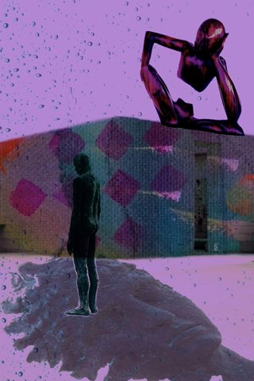

Once inside there was a large round table covered by a dark indigo cloth with needlepoint stars and a full moon. A crystal ball was in the center with a stack of cards laying atop a white silk scarf. The only light was from thickly dripping candles placed all about. The smell in the air was new to me, it wasn't perfume but what I now know as incense. Since my grandmother was a tarot reader I did kind of recognize the size of the cards, but the backs were new to me. Sue did not know about my grandmother and her tarot readings, nor my interest in tarot. From behind a beaded curtain entered an older lady covered in colorful veils and jewelry and tattoos. As if stepping from a gypsy wagon. She said to please call her Madame, and she only accepted donations not payment. Madame asked if one of us had a question for her. Madame also never stopped staring at me. Did I know her, did my grandmother know her, I wondered. Sue looked at me, I suppose because I was paying for everything, I shook my head no. Sue thought. While Madame riffle shuffled, Sue asked a question.

Would we marry and live happily ever after?

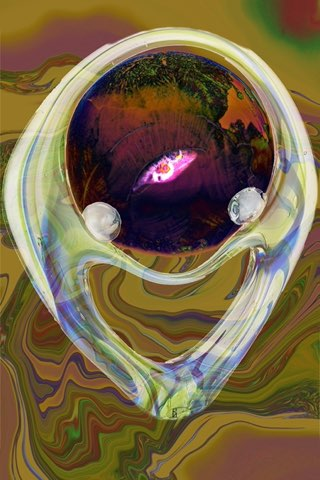

Madame stopped shuffling and placed the deck on the table face down. She asked Sue to cut the cards into three piles. Sue did, as she glanced at me sideways, I suppose, to gauge my reaction to her question. I had none, a bit startled perhaps. Madame stared at me, as if angry now, as she gathered up the piles into one again. I do remember feeling over heated, maybe from the rides and too much sugar. Madame now fanned out all of the cards in a perfect arc on the table. Her hands went back and forth over the cards as she plucked one from here and another from there. She placed seven cards face down in a horseshoe shape with the opening facing me and Sue. My grandmother had never done it this way, that I knew of. Yet another first.

Madame's interpretation of those cards led her to say that no we would not marry and further that our lives would not be all that happy, whether we stayed together or not. She was blunt, succinct, and to the point. No snake oil or sugar coating in her sideshow. I donated ten dollars. Sue seemed sad and left the tent. I lingered to ask Madame what that tarot deck was, it was the Thoth by Aleister Crowley. She said thank you for the donation, then added how disappointed it made her that I had not asked the question that was in my heart. I simply left to find Sue. There she stood, changed somehow. We left. I took her home. I never saw her again. Brief moments from long ago, a simple memory, nothing profound, nothing spectacular, yet it's shimmer lingers.

# CHAPTER 20

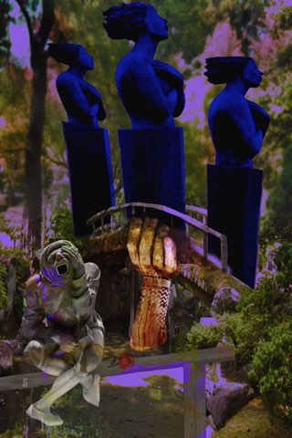

## There I was doing something way out of character for me.

A live chat stream interview on YouTube with two guests. Never saw that coming. My guests were a man, I suspected of being a wizard, and his pet Cockatiel bird. The man's name was Wobeegon and he was at least seven feet tall. Always with a long cane, he called a wand, that had a large clear crystal on top. Covering his left arm was a sleeve of multiple layers of thick leathers to protect his skin from the bird's claws and beak. She, the bird, was named Smidgens. She talked, a lot. Sometimes carrying on what felt like real conversations.

So there we were; interacting in a live chat, talking about this and that, reading back viewers comments, but mostly listening to Smidgens talk. It took a handful of tough to crack nuts to keep her quiet. The wizard wanted to try something on camera. This live chat already seemed strange enough, now what, but first some background.

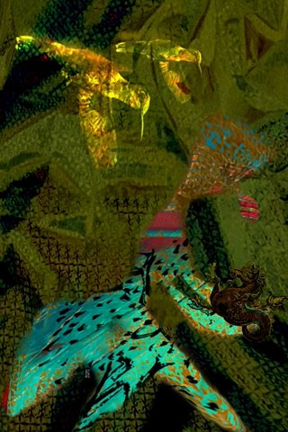

Wobeegon and Smidgens spent much of their daylight hours walking around our tiny town. That's how we met, since I jog everyday our paths crossed many times over the years. Our first meeting was on a very hot summer day. I had jogged around the high school track that day with my shirt off. Because of childhood scars on the left side of my back, I don't go shirtless very often in public. It draws too much attention, questions, all of which lead to bad memories. There I was doing some after run stretches at the parallel bars when a big white bird landed on a bar. It eyed me then blurted out all at once

"Hello. Wazzup? What's your name? Me Smidgens".

I stood up and looked around. As if out of nowhere, right behind me, there was a very tall man with a odd looking cane. Smidgens said "Why rude?". I was startled but introduce myself to both bird and man. He noticed my back, but only remarked about the faint fern-like pattern scars. He recognized them as scars from lightning or high voltage shocks. I told him that I had experience both of those many years ago. He had some thoughts about people and the affects of after shocks, as he called them. His opinion was that once shocked you were more susceptible to future shocks. This would all lead to his experiment during the YouTube live chat, so back to the interview.

[figure not shown]

Smidgens remained mostly quiet while fretting over those nuts. Wobeegon proposed to conjure some static electricity using his wand, the cane. To be forever captured on video, maybe. I said sure, fully aware that if it did work it would only be a weak piezoelectric effect and display, so not all that dangerous. Except for a candle, I turned off the lights. We both stood up. I refocused the camera to capture everything. We were about three feet apart. He grab the cane by the crystal ball on top, touched me in the chest with the other end. Pulled it back then sharply stabbed it into the floor. Then a faint bluish white bolt emitted from the crystal cracking dead bang into my chest near my heart. It was more intense than I expected, dazed me, but surprised me mostly. I felt a warm spot near my heart, so I pulled down the neck of my tee shirt to reveal an oval reddish rash-like spot about palm size. This is when Smidgens said, as clear as could be, "Christopher, never trust a wizard!". The wizard had sat down, now with a sinister look on his face.

Alas, the video went viral, as they say, with millions of views.

I vanished from YouTube, that was my last video.

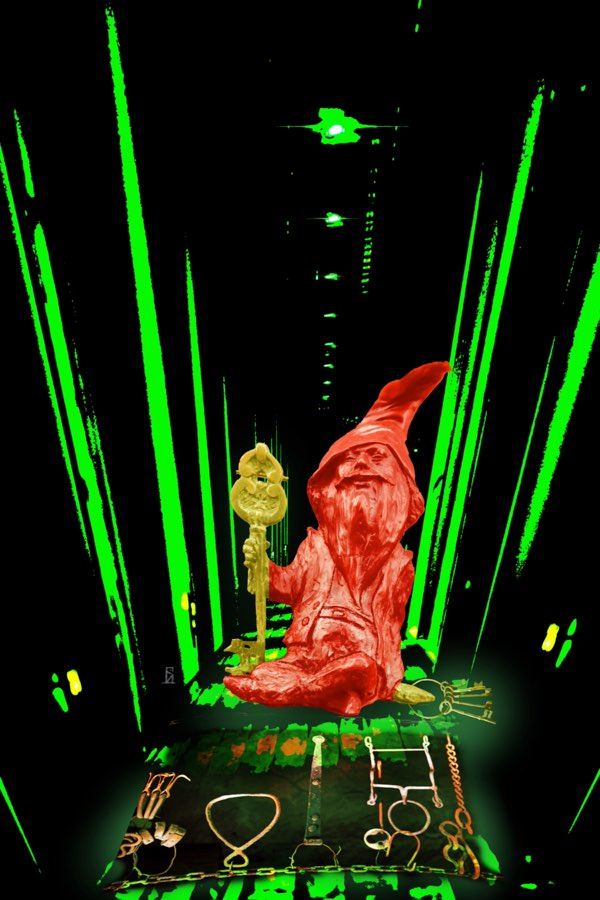

# ABOUT THE AUTHOR

This book is my first attempt at writing very short stories, vignettes. Most of them are based on true life events but embellished to be more readable as a story. You will of course notice many mistakes: grammar, sentences fragments, and an overall lack of craft and style. However, more experienced and established authors have read these stories and generously offered their encouragement. Hopefully a day will come when craft and style begin to take form. So, at this point, I wanted to document my current state of affairs as a writer, and someday it might be entertaining to look back on this first effort. How many authors have been brave or stupid enough to have done this?

*For more information:*

www.slipthetrap.com

Digital collage artworks:

slip-the-trap.pixels.com

For all your freely given help, with love to, Linda A. Lavid.

[YouTube](https://www.youtube.com/@slipthetrap)